# *Hope and Fear*

Philosophy 101 - Class 25

Brian Weatherson

weath@umich.edu

University of Michigan

November 28, 2023

# Quick Reprise

## Testimony

Last time we discussed a puzzle about testimonial knowledge.

1. It’s good to trust people who are reliable, and distrust people who are unreliable.
2. It’s bad to be in epistemic bubbles, where you agree with everyone around you, and disagree with people outside your bubble.
3. People aren’t magically labeled as reliable or unreliable. To think someone’s reliable just is to agree with them a lot.

## Three Kinds of Approaches

We went over these a little in the lecture, and will go over them more next week.

1. Look for red flags.
2. Pay more attention to people who disagree with you a bit.
3. Do an audit every so often.

And this isn’t meant to be a comprehensive list.

# Emotions

## Three Big Questions

Which emotions are

1. Helpful
2. Healthy
3. Fitting/Apt/Appropriate

Let’s describe those in a bit more detail

## Helpful

Having, or expression, some emotions might contribute to making the world a better place.

Perhaps if the crowd of protestors shows the government that they are **angry**, the government will change plans and things will be better.

## Healthy

Having (and to a lesser extent expressing) some emotions can contribute to the quality of one’s own life.

Sometimes this is fairly direct. - Someone who feels a lot of **resentment** is often unhappy.

Sometimes it is more indirect. - There is some evidence that for some diseases, patients who are **hopeful** have a higher recovery rate.

## Fitting

There is something right about **fearing** scary things, **admiring** admirable people, being **outraged** at the outrageous, and so on.

And there is something wrong about **fearing** things that aren’t scary, **admiring** people who aren’t admirable, being **outraged** at things that aren’t outrageous, and so on.

Call this ‘something’ that the emotions are **fitting**.

## Fitting

The important thing is that this is meant to be independent of the consequences of holding the emotion.

Maybe it’s not helpful to the world or healthy for you to be outraged by some outrageous thing on the news.

But it might still be fitting, if the thing really is outrageous.

## Metaphysics

Now this raises delicate questions about

- What is it for something to be outrageous? Is it a real property of the thing, or just that a lot of people like us get outraged by it?
- What is good about attitudes being fitting in this sense, if they aren’t helpful or healthy?

For now we’ll set those aside, and primarily talk about what’s **helpful**.

## Helpful and Fitting

There is a nice example in the paper to remember the difference here. A hiker is lost in perilous conditions, with a low chance of survival.

- The **fitting** attitude is to be very pessimistic about their chances of survival.
- The **helpful** and arguably **healthy** attitude is to be optimistic, because that will (probably) encourage them taking actions that maximise the chance of their own survival.

# Fear and Hope

## Which is More Helpful?

Imagine two kinds of campaigns around climate change.

1. Fear-based
2. Hope-based

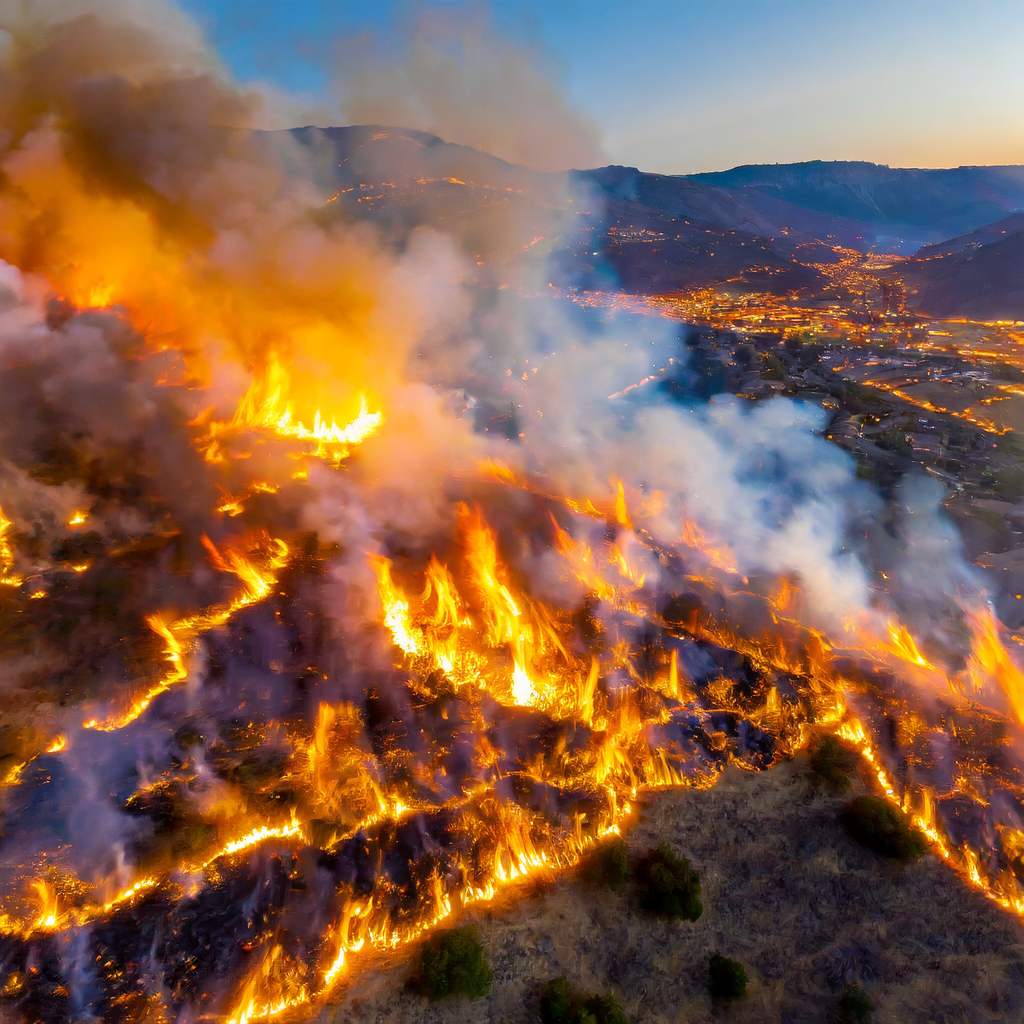

AI image of wildfire

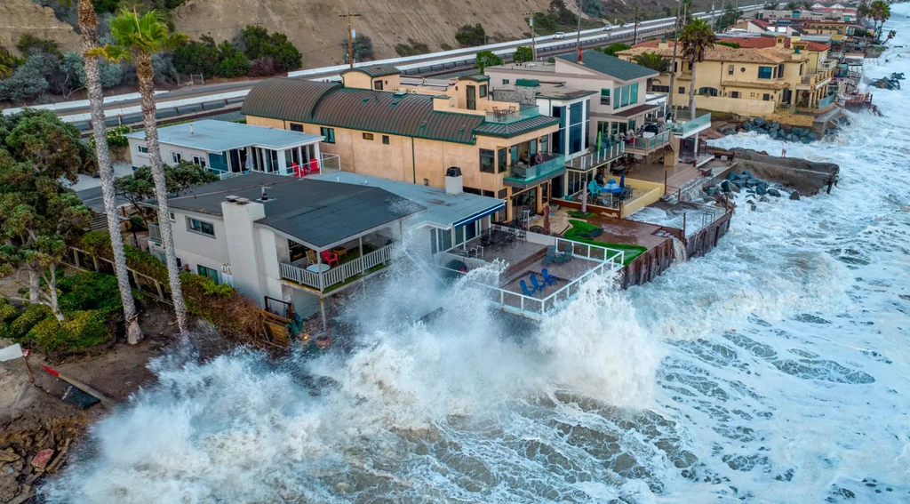

## Fear Based

If we don’t do something about climate change

- Fires will be more prevalent
- Sea levels will rise and storms will be more prevalent
- Perhaps billions of people will be displaced, leading to political unrest and probably violence

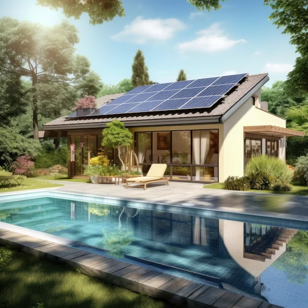

AI image of solar panels

## Hope Based

We know how to fix climate change:

1. Electrify everything
2. Make electricity carbon-neutral

## Hope Based

The technology for this exists and is getting cheaper every year:

- Solar panels
- Wind turbines
- Battery

Without storage, these are *cheaper* sources of energy than coal or gas; with storage they are pretty competitive.

## Hope Based

And doing this has benefits independent of climate change:

- Less pollution means less disease
- A more distributed electricity network is more resilient
- And everyone having solar panels means less need for unsightly, and unsafe, power poles and lines.

## Question

Which kind of campaign is (a) morally preferable, and (b) more likely to be successful?

## iClicker

Which kind of campaign do you find more persuasive

1. Fear
2. Hope

## False Dichotomies

We’re going to simplify by talking about these as competing approaches, but that’s a real simplification.

Why not both? is a perfectly reasonable answer.

But even then, there’s a question of emphasis; what mix of fear and hope do you have.

And it simplifies the discussion to just look at the extremes; hopefully what we say will extend to the more realistic cases.

# Fear

## What a Fear Campaign is Like

The plan for today is to talk about what features a fear campaign has, and look at three possible downsides.

On Thursday we’ll go over the responses to those downsides, and then do the same for hope.

## Four features of fear

- Susceptible
  - Something bad might happen to **you**.
- Severe
  - The bad thing will be **very** bad.
- Effective
  - There is something that can prevent the bad thing.
- Power
  - You have the power to do that something

## Severe

Two kinds of severe threat.

1. Improbable but extremely harmful.
2. Moderately harmful and very probable.

It could of course be both.

## Power

Doing all this in English blurs an important point about power. The following two things are different.

1. There is something that, if we all do it, will blunt the threat.
2. There is something that you personally can do that will make a noticeable difference to the threat.

Speaking a language that doesn’t have a distinctive second-person plural blurs this, especially in the context of public campaigns.

## Climate Change and Health Crises

This is a big difference between climate change and public health campaigns, either about AIDS or Covid.

- In health crises there typically is something that you personally can do.
- This was especially true during AIDS, when there were very clear ways to reduce (if not eliminate) personal risk.
- Climate change is obviously not like that.

## Three Downsides to Fear

1. Fear-mongering
2. Forced choice
3. Counterproductive

We’ll say a bit more about each of these, then go over them in more detail next time.

## Fear-Mongering

Fear campaigns can produce

1. False beliefs, as arguably happens with campaigns about crime.
2. Irrational beliefs, as maybe happened during AIDS.
3. Manipulated beliefs, when people are tricked into believing what they arguably should belief.

## Forced Choice

A fear campaign can be undemocratic, making people feel they don’t have a choice.

## Counterproductive

A fear campaign can make people resigned, thinking it is too late to do anything about the problem.

## For Next Time

We’ll go over these in more detail, and compare them to using hope as a central strategy.